# TRABAJO FINAL MODULO 5

Raquel Pacheco

2023-05-28

## **CLÚSTER JERÁRQUICO**

Del archivo BOL_BP_MAY_2017 seleccione los siguientes indicadores, para los bancos, sin considerar las columnas de TOTALES. Activos productivos/total activos Morosidad cartera total Gastos de Operación/Margen Financiero Rentabilidad del ejercicio/ activo promedio Fondos disponibles/total depositos corto plazo Construya un cluster jerarquico. Grafique y comente su composición, usando al menos 2 distancias y dos métodos de clasificación Construya un cluster no jerarquico. Determine el número óptimo de clusters, grafique y comente.

### Carga de las librerias

```r
library(openxlsx)
library(cluster)
library(usethis)
library(devtools)
library(ggplot2)
library(factoextra)
library(fpc)
library(dplyr)
library(NbClust)
```

### Carga y manipulacion de la base de datos

```r
data<-read.xlsx("C:\\Users\\CompuStore\\Desktop\\CURSOS\\CIENCIA DE DATOS\\MODULO 5\\parte 2\\BOL_BP_MAY_ 2017.xlsx",
                sheet = "INDICADORES")

# Eliminamos filas
data<-slice(data, -c(1:3, 5))

#Eliminamos las columnas de bancos de totales
data<-data[,-1]
data<-data[,-6]
data<-data[,-15]
data<-data[,-c(25:30)]


#Seleccionamos las variables a utilizar

data<-data %>%
  filter(data$INDICADORES.FINANCIEROS=="NOMBRE DEL INDICADOR"|
    data$INDICADORES.FINANCIEROS=="ACTIVOS PRODUCTIVOS / TOTAL ACTIVOS"|
           data$INDICADORES.FINANCIEROS=="MOROSIDAD DE LA CARTERA TOTAL"|
           data$INDICADORES.FINANCIEROS=="GASTOS DE OPERACION  / MARGEN FINANCIERO"|
           data$INDICADORES.FINANCIEROS=="RESULTADOS DEL EJERCICIO / ACTIVO PROMEDIO"|
           data$INDICADORES.FINANCIEROS=="FONDOS DISPONIBLES / TOTAL DEPOSITOS A CORTO PLAZO")

# Trasponemos nuestra base
data<- data.frame(t(data))

# Convertimos la fila en el nombre de la columna
colnames(data) <- data[1, ]
data <- data[-1, ]

#Guardamos en una variable el nombre de los bancos
nombres<-data$`NOMBRE DEL INDICADOR`


#Ponemos en formato numerico
base<-as.data.frame(lapply(data[,-1], as.numeric))

# Estandarizamos
base<-data.frame(scale(base))

#Convertimos como indice a los nombres
row.names(base)<-nombres
```

### Clúster Jerárquico - Distancia Euclidean y Método WAR.D

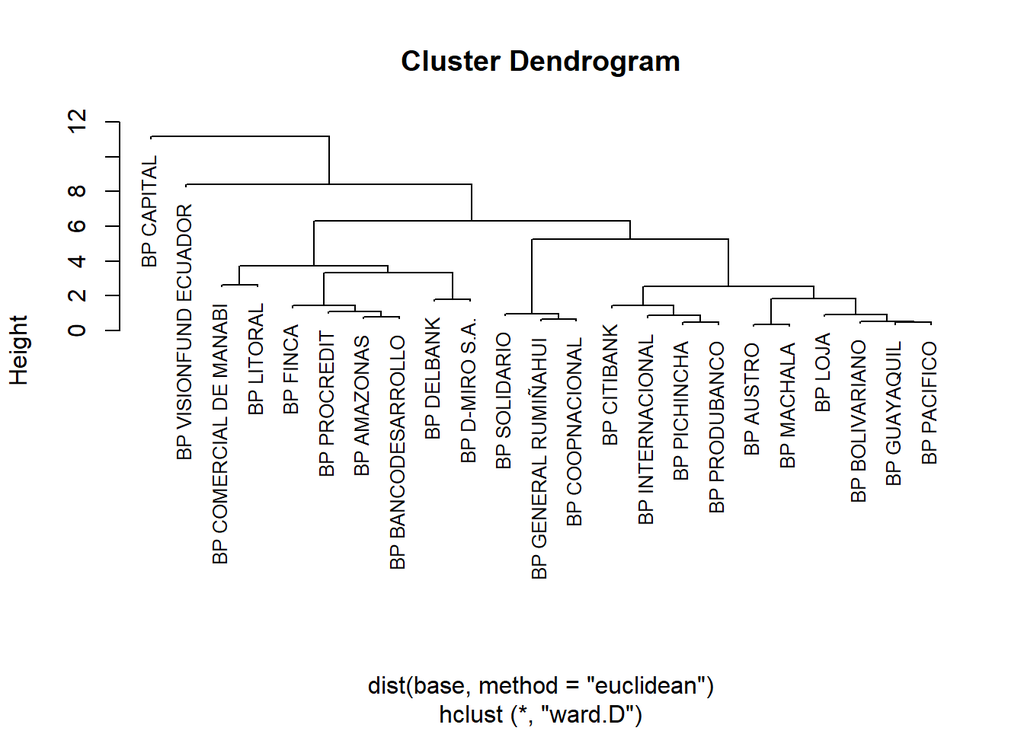

```r
cluster<-hclust(dist(base, method = "euclidean"),
                method = "ward.D")

plot(cluster, hang = 0.01, cex=0.8)
```

El dendograma sirve para clasifcar a un grupo dentro de un cluster, en este podemos observar que una primera instancia podrian haber 4 grupos formados, de los cuales en un primer nivel tenemos a los bancos BP GUAYAQUIL, BP PACIFICO, BP PICHINCHA, BP BOLIVARIANO, BP LOJA, BP MACHALA, BP AUSTRO, BP PRODUBANCO, BP INTERNACIONAL, BP CITIBANK, BP COOPNACIONAL, BP GENERAL RUMIÑAHUI y BP SOLIDARIO, los cuales están agrupados es decir comparten similitudes o características comunes según la medida de similitud; la distancia euclideana en este caso utilizada. Por otra parte, tenemos a los bancos BP DELBANK, BP D-MIRO S.A. BP AMAZONAS,BP PROCREDIT, BP FINCA, BP BANCODEDESARROLLO, BP COMERCIAL DE MANABI, BP LITORAL, que podrían ser otro grupo, sin embargo, vemos que después estos 2 grupos se unen y forman uno solo, por lo que podriamos decir que practicamente sus distancias no son tan lejanas y a la final podriamos tener un dendograma con 3 grupos. Esto lo iremos viendo a medida que hacemos otros calculos. No obstante, podemos visualizar que el banco BP VISONFUND ECUADOR, pertenece a un solo grupo y de la misma manera el banco BP CAPITAL pertenece a otro grupo. Todos estos grupos estaban basados en la distancia euclideana y el metodo ward.

### Clúster Jerárquico - Distancia Manhattan y Método Average

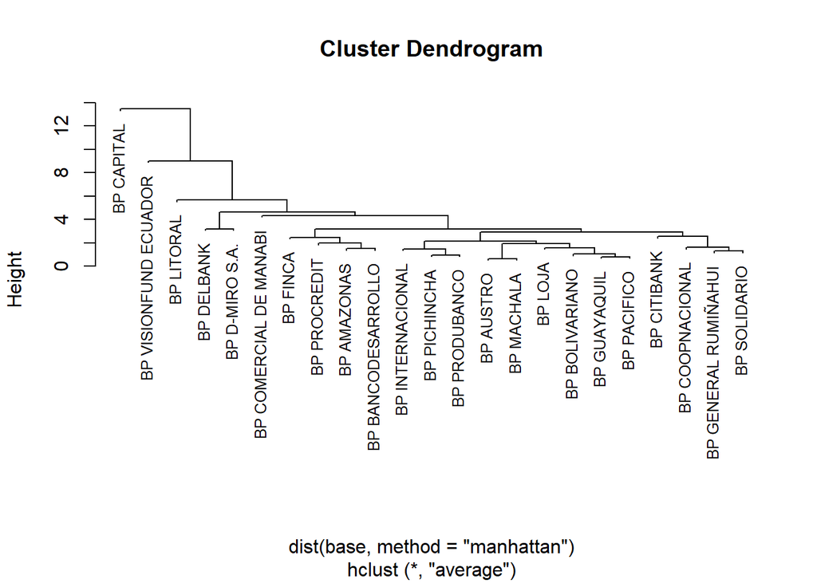

```r
# Cambiamos el método

cluster2<-hclust(dist(base, method = "manhattan"),
                 method = "average")

plot(cluster2, hang = 0.01, cex=0.8)
```

A diferencia del dendograma anterior utilizado otra distancia y otro método, en este caso, vemos que los grupos se han unido similarmente, por ejemplo tenemos que BP CAPITAL Y BP VISONFUND ECUADOR siguen siendo grupos separados, no obstante, visualizamos que la distancia manhattan y el metodo de averange en BP LITORAL a diferencia del anterior, forma un grupo aparte.

### Ambos dendogramas

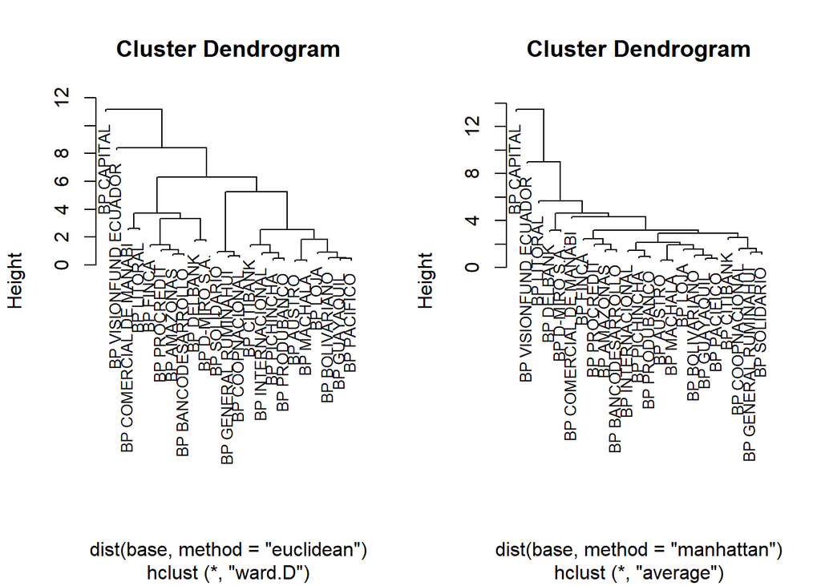

```r
# En una sola ventana los 2 graficos

par(mfrow=c(1,2))

cluster<-hclust(dist(base, method = "euclidean"),
                method = "ward.D")

plot(cluster, hang = 0.01, cex=0.8)

cluster2<-hclust(dist(base, method = "manhattan"),
                 method = "average")

plot(cluster2, hang = 0.01, cex=0.8)
```

### ¿A qué distancia se encuentran los elementos?

```r
## Distancia euclideana
distancia<- dist(base, method = "euclidean")
distancia
```

```
                       BP GUAYAQUIL BP PACIFICO BP PICHINCHA BP PRODUBANCO
BP PACIFICO               0.4715003
BP PICHINCHA              0.8785435   1.0935979
BP PRODUBANCO             0.7379580   0.9393174    0.4767129
BP AUSTRO                 1.0573832   0.9794326    1.0449852     0.8369484
BP BOLIVARIANO            0.5040926   0.5567835    1.1858166     0.8454229
BP CITIBANK               1.1245269   1.5118524    1.2806900     1.3777129
BP GENERAL RUMIÑAHUI      1.6718961   2.1150689    1.3777317     1.5593343
BP INTERNACIONAL          1.0160265   1.3889851    0.7255328     0.8169216
BP LOJA                   0.5963260   0.7719030    1.2048287     1.2322989
BP MACHALA                0.9227118   0.8085230    1.1300202     0.8020579
BP SOLIDARIO              1.9186287   2.3113456    1.5014414     1.7334983
BP PROCREDIT              1.7367900   1.7639686    1.3948263     1.2570655
BP AMAZONAS               1.3925151   1.4940282    0.9179306     0.9433115
BP COMERCIAL DE MANABI    2.1206653   1.7193069    2.3800884     2.2139159
BP LITORAL                3.3535528   3.2759740    3.0778102     2.9393290
BP COOPNACIONAL           2.0955541   2.5216203    1.6647480     1.7867697
BP CAPITAL                7.1733455   6.9640148    6.9757352     6.9645023
BP FINCA                  1.8865786   2.1532919    1.1487547     1.4025217
BP DELBANK                1.9381527   1.9192333    2.2675743     2.2427764
BP D-MIRO S.A.            2.7991454   2.9763989    2.5624730     2.7045470
BP BANCODESARROLLO        1.8879969   2.1006924    1.4466337     1.4828618
BP VISIONFUND ECUADOR     5.0692811   5.3945478    5.4155376     5.4523256
                       BP AUSTRO BP BOLIVARIANO BP CITIBANK
BP PACIFICO
BP PICHINCHA
BP PRODUBANCO
BP AUSTRO
BP BOLIVARIANO         1.0421944
BP CITIBANK            2.0527156      1.4546069
BP GENERAL RUMIÑAHUI   2.1724215      2.0004076   1.0994098
BP INTERNACIONAL       1.5575170      1.3080080   0.8742536
BP LOJA                1.3387701      0.9966959   1.2507270
BP MACHALA             0.3648149      0.7558290   1.9677780
BP SOLIDARIO           2.1105068      2.2622996   1.6919220
BP PROCREDIT           1.0884036      1.6932444   2.4090684
BP AMAZONAS            0.7318459      1.5411921   2.0725232
BP COMERCIAL DE MANABI 1.5378834      1.9838548   3.2127823
BP LITORAL             2.3201313      3.2562004   4.2258036
BP COOPNACIONAL        2.4546939      2.3388504   1.5477392
```

[output cut: 106 more lines]

```
BP INTERNACIONAL
BP LOJA
BP MACHALA
BP SOLIDARIO
BP PROCREDIT
BP AMAZONAS
BP COMERCIAL DE MANABI
BP LITORAL
BP COOPNACIONAL
BP CAPITAL
BP FINCA
BP DELBANK
BP D-MIRO S.A.
BP BANCODESARROLLO
BP VISIONFUND ECUADOR           5.1791109
```

```r
# ¿A qué grupo pertenecen los clúster?

cluster$merge
```

```
      [,1] [,2]
 [1,]   -5  -11
 [2,]   -1   -2
 [3,]   -3   -4
 [4,]   -6    2
 [5,]   -8  -17
 [6,]  -14  -22
 [7,]   -9    3
 [8,]  -10    4
 [9,]  -12    5
[10,]  -13    6
[11,]   -7    7
[12,]  -19   10
[13,]  -20  -21
[14,]    1    8
[15,]   11   14
[16,]  -15  -16
[17,]   12   13
[18,]   16   17
[19,]    9   15
[20,]   18   19
[21,]  -23   20
[22,]  -18   21
```

```r
## ¿A qué distancia se encuentran los elementos?
## Distancia manhattan
distancia2<- dist(base, method = "manhattan")
distancia2
```

```
                       BP GUAYAQUIL BP PACIFICO BP PICHINCHA BP PRODUBANCO
BP PACIFICO               0.7997011
BP PICHINCHA              1.6895871   1.7431547
BP PRODUBANCO             1.5144362   1.7806311    0.9744719
BP AUSTRO                 2.0404339   1.9292834    2.0531594     1.6838460
BP BOLIVARIANO            0.9753776   1.1214854    2.3857374     1.5899290
BP CITIBANK               2.0737810   2.8634502    2.6703036     2.7204109
BP GENERAL RUMIÑAHUI      2.0449117   2.8446128    2.6514662     2.7015734
BP INTERNACIONAL          1.7850684   2.3081968    1.4386835     1.5561624
BP LOJA                   1.1289129   1.6948723    2.4987944     2.6433492
BP MACHALA                1.7254383   1.2748909    1.9738901     1.6045767
BP SOLIDARIO              2.5917604   2.9240905    2.5080030     3.0534702
BP PROCREDIT              3.2349321   3.2884996    2.3547668     2.0619704
BP AMAZONAS               3.0571331   3.1107006    1.6632721     1.7183511
BP COMERCIAL DE MANABI    4.2477758   3.4480747    3.9370355     3.5911141
BP LITORAL                6.0759900   6.1295576    5.2368809     5.0916561
BP COOPNACIONAL           2.9394744   3.3910237    2.7721467     2.8222539
BP CAPITAL               13.6996950  12.8999939   13.7012531    13.3319398
BP FINCA                  3.4697001   3.5232676    1.7801129     2.5477237
BP DELBANK                3.6074265   3.5897835    4.2056459     3.8363325
BP D-MIRO S.A.            5.7574037   6.0875440    5.2725905     5.3041894
BP BANCODESARROLLO        3.7564108   3.9909146    3.1759611     3.2075600
BP VISIONFUND ECUADOR     8.3462576   8.7851314    8.4849064     9.0303735
                        BP AUSTRO BP BOLIVARIANO BP CITIBANK
BP PACIFICO
BP PICHINCHA
BP PRODUBANCO
BP AUSTRO
BP BOLIVARIANO          2.1268628
BP CITIBANK             4.1041830      2.5079950
BP GENERAL RUMIÑAHUI    4.0853456      2.7885955   1.9046048
BP INTERNACIONAL        3.2400085      2.3279730   1.5623558
BP LOJA                 2.2922130      1.9089903   2.3374127
BP MACHALA              0.6543924      1.4724704   3.7891875
BP SOLIDARIO            3.3016532      3.3400722   3.2149646
BP PROCREDIT            1.9524041      3.4860791   4.5400440
BP AMAZONAS             1.1969482      3.3082801   3.9535293
BP COMERCIAL DE MANABI  2.2723309      3.9877476   6.3115249
BP LITORAL              4.2002742      6.3271370   7.8120669
BP COOPNACIONAL         4.2496452      3.2289191   2.4977696
```

[output cut: 106 more lines]

```
BP INTERNACIONAL
BP LOJA
BP MACHALA
BP SOLIDARIO
BP PROCREDIT
BP AMAZONAS
BP COMERCIAL DE MANABI
BP LITORAL
BP COOPNACIONAL
BP CAPITAL
BP FINCA
BP DELBANK
BP D-MIRO S.A.
BP BANCODESARROLLO
BP VISIONFUND ECUADOR           9.1838672
```

```r
# ¿A qué grupo pertenecen los clúster?

cluster2$merge
```

```
      [,1] [,2]
 [1,]   -5  -11
 [2,]   -1   -2
 [3,]   -3   -4
 [4,]   -6    2
 [5,]   -8  -12
 [6,]   -9    3
 [7,]  -14  -22
 [8,]  -10    4
 [9,]  -17    5
[10,]    1    8
[11,]  -13    7
[12,]    6   10
[13,]  -19   11
[14,]   -7    9
[15,]   12   14
[16,]  -20  -21
[17,]   13   15
[18,]  -15   17
[19,]   16   18
[20,]  -16   19
[21,]  -23   20
[22,]  -18   21
```

### Cortes

```r
# Realizando cortes

cutree(cluster, k=3)
```

```
          BP GUAYAQUIL            BP PACIFICO           BP PICHINCHA
                     1                      1                      1
         BP PRODUBANCO              BP AUSTRO         BP BOLIVARIANO
                     1                      1                      1
           BP CITIBANK   BP GENERAL RUMIÑAHUI       BP INTERNACIONAL
                     1                      1                      1
               BP LOJA             BP MACHALA           BP SOLIDARIO
                     1                      1                      1
          BP PROCREDIT            BP AMAZONAS BP COMERCIAL DE MANABI
                     1                      1                      1
            BP LITORAL        BP COOPNACIONAL             BP CAPITAL
                     1                      1                      2
              BP FINCA             BP DELBANK         BP D-MIRO S.A.
                     1                      1                      1
    BP BANCODESARROLLO  BP VISIONFUND ECUADOR
                     1                      3
```

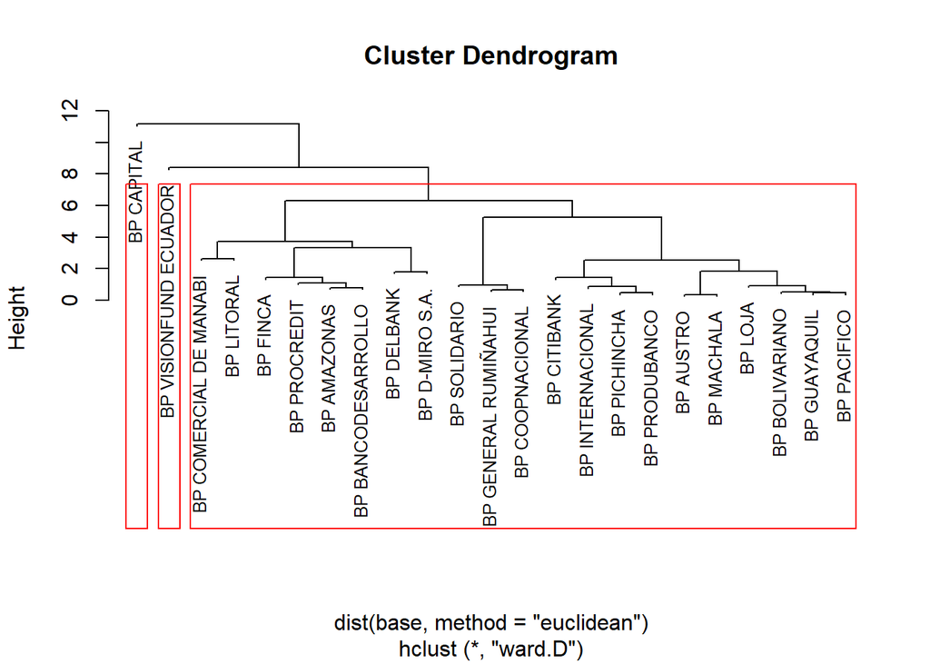

```r
plot(cluster, hang = 0.01, cex=0.8)
rect.hclust(cluster, k=3, border = "red")
```

```r
# ¿A que grupo pertenecen?

grupos<-as.data.frame(cutree(cluster, k=3))
grupos
```

```
                       cutree(cluster, k = 3)
BP GUAYAQUIL                                1
BP PACIFICO                                 1
BP PICHINCHA                                1
BP PRODUBANCO                               1
BP AUSTRO                                   1
BP BOLIVARIANO                              1
BP CITIBANK                                 1
BP GENERAL RUMIÑAHUI                        1
BP INTERNACIONAL                            1
BP LOJA                                     1
BP MACHALA                                  1
BP SOLIDARIO                                1
BP PROCREDIT                                1
BP AMAZONAS                                 1
BP COMERCIAL DE MANABI                      1
BP LITORAL                                  1
BP COOPNACIONAL                             1
BP CAPITAL                                  2
BP FINCA                                    1
BP DELBANK                                  1
BP D-MIRO S.A.                              1
BP BANCODESARROLLO                          1
BP VISIONFUND ECUADOR                       3
```

```r
## cluster

ncluster<-diana(base, metric="euclidean")

par(mfrow=c(1,2))
```

### Dendograma Final

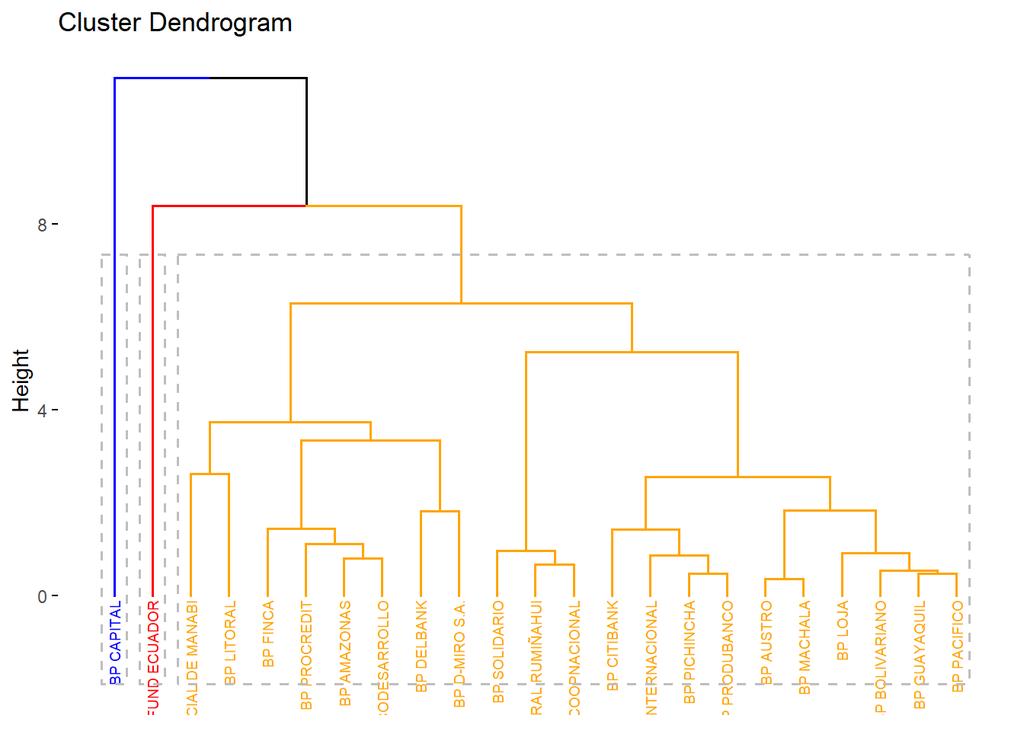

```r
cluster1<- hcut(base, k=3, stand=TRUE,
                hc_metric = "euclidean",
                hc_method = "ward.D")
fviz_dend(cluster1, rect=1, cex= 0.5,
          k_colors = c("blue", "red", "orange")
)
```

## **CLÚSTER NO JERÁRQUICO - CLÚSTER K-MEDIAS**

### Cluster

```r
## cluster
cnj<-kmeans(base,3)
cnj
```

```
K-means clustering with 3 clusters of sizes 1, 5, 17

Cluster means:
  ACTIVOS.PRODUCTIVOS...TOTAL.ACTIVOS MOROSIDAD.DE.LA.CARTERA.TOTAL
1                          -1.8127067                    3.59686390
2                           1.2062846                   -0.58778421
3                          -0.2481598                   -0.03870252
  GASTOS.DE.OPERACION....MARGEN.FINANCIERO
1                               4.13445549
2                              -0.54098996
3                              -0.08408857
  RESULTADOS.DEL.EJERCICIO...ACTIVO.PROMEDIO
1                                 -2.8225866
2                                  0.9531444
3                                 -0.1143021
  FONDOS.DISPONIBLES...TOTAL.DEPOSITOS.A.CORTO.PLAZO
1                                         -0.3471037
2                                          0.7484362
3                                         -0.1997104

Clustering vector:
          BP GUAYAQUIL            BP PACIFICO           BP PICHINCHA
                     3                      3                      3
         BP PRODUBANCO              BP AUSTRO         BP BOLIVARIANO
                     3                      3                      3
           BP CITIBANK   BP GENERAL RUMIÑAHUI       BP INTERNACIONAL
                     2                      2                      3
               BP LOJA             BP MACHALA           BP SOLIDARIO
                     3                      3                      2
          BP PROCREDIT            BP AMAZONAS BP COMERCIAL DE MANABI
                     3                      3                      3
            BP LITORAL        BP COOPNACIONAL             BP CAPITAL
                     3                      2                      1
              BP FINCA             BP DELBANK         BP D-MIRO S.A.
                     3                      3                      3
    BP BANCODESARROLLO  BP VISIONFUND ECUADOR
                     3                      2

Within cluster sum of squares by cluster:
[1]  0.00000 18.95853 29.73459
 (between_SS / total_SS =  55.7 %)

Available components:

[1] "cluster"      "centers"      "totss"        "withinss"     "tot.withinss"
[6] "betweenss"    "size"         "iter"         "ifault"
```

```r
#Media de cada cluster

cnj$centers
```

```
  ACTIVOS.PRODUCTIVOS...TOTAL.ACTIVOS MOROSIDAD.DE.LA.CARTERA.TOTAL
1                          -1.8127067                    3.59686390
2                           1.2062846                   -0.58778421
3                          -0.2481598                   -0.03870252
  GASTOS.DE.OPERACION....MARGEN.FINANCIERO
1                               4.13445549
2                              -0.54098996
3                              -0.08408857
  RESULTADOS.DEL.EJERCICIO...ACTIVO.PROMEDIO
1                                 -2.8225866
2                                  0.9531444
3                                 -0.1143021
  FONDOS.DISPONIBLES...TOTAL.DEPOSITOS.A.CORTO.PLAZO
1                                         -0.3471037
2                                          0.7484362
3                                         -0.1997104
```

```r
# Usando agregate

aggregate(base, by= list(cnj$cluster), FUN = mean)
```

```
  Group.1 ACTIVOS.PRODUCTIVOS...TOTAL.ACTIVOS MOROSIDAD.DE.LA.CARTERA.TOTAL
1       1                          -1.8127067                    3.59686390
2       2                           1.2062846                   -0.58778421
3       3                          -0.2481598                   -0.03870252
  GASTOS.DE.OPERACION....MARGEN.FINANCIERO
1                               4.13445549
2                              -0.54098996
3                              -0.08408857
  RESULTADOS.DEL.EJERCICIO...ACTIVO.PROMEDIO
1                                 -2.8225866
2                                  0.9531444
3                                 -0.1143021
  FONDOS.DISPONIBLES...TOTAL.DEPOSITOS.A.CORTO.PLAZO
1                                         -0.3471037
2                                          0.7484362
3                                         -0.1997104
```

## Como se ven los grupos

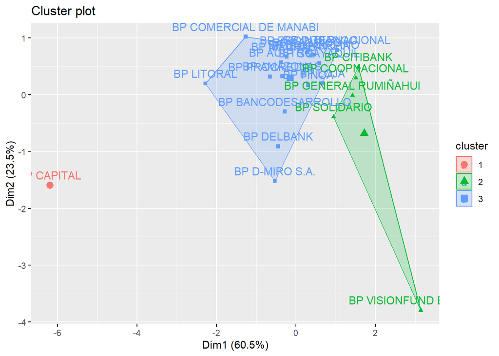

```r
fviz_cluster(cnj, data=base)
```

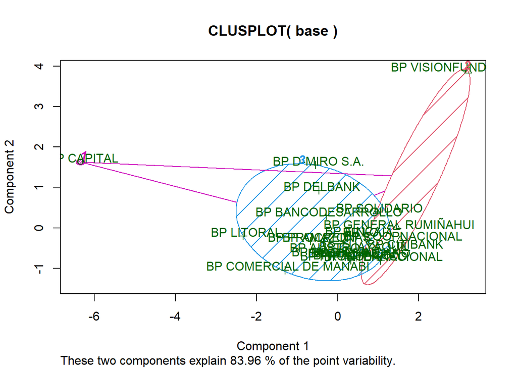

```r
require(cluster)
clusplot(base, cnj$cluster,
         color=T, shade = T,
         labels = 2, lines = 2)
```

### ¿Cuantos cluster son los optimos?

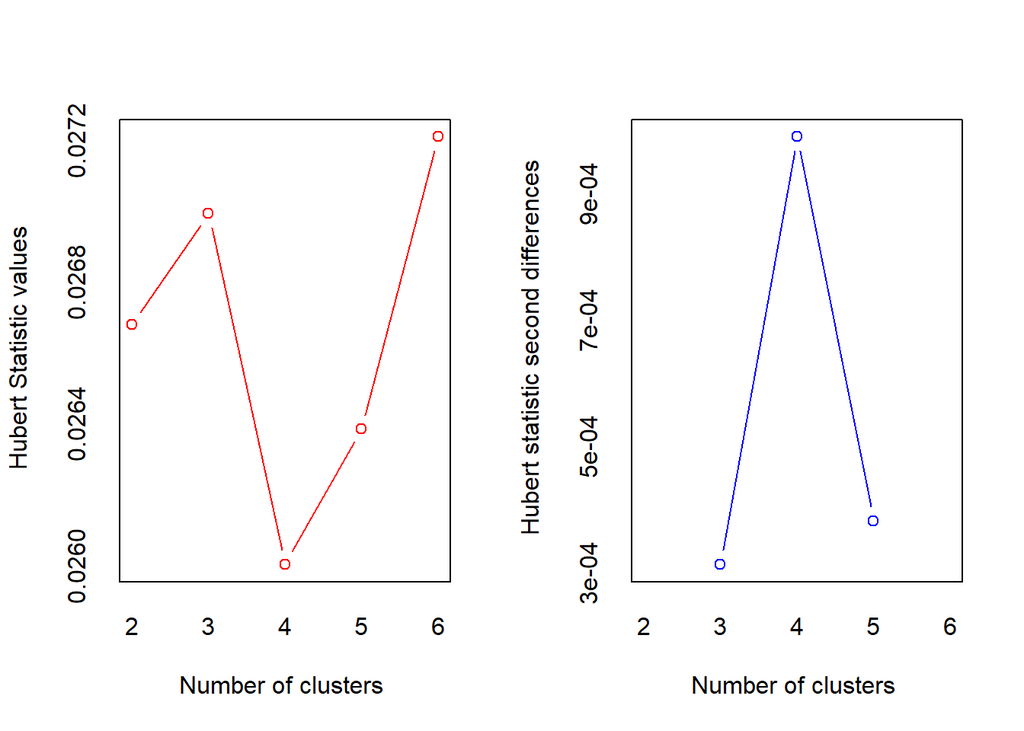

```
*** : The Hubert index is a graphical method of determining the number of clusters.
                In the plot of Hubert index, we seek a significant knee that corresponds to a
                significant increase of the value of the measure i.e the significant peak in Hubert
                index second differences plot.
```

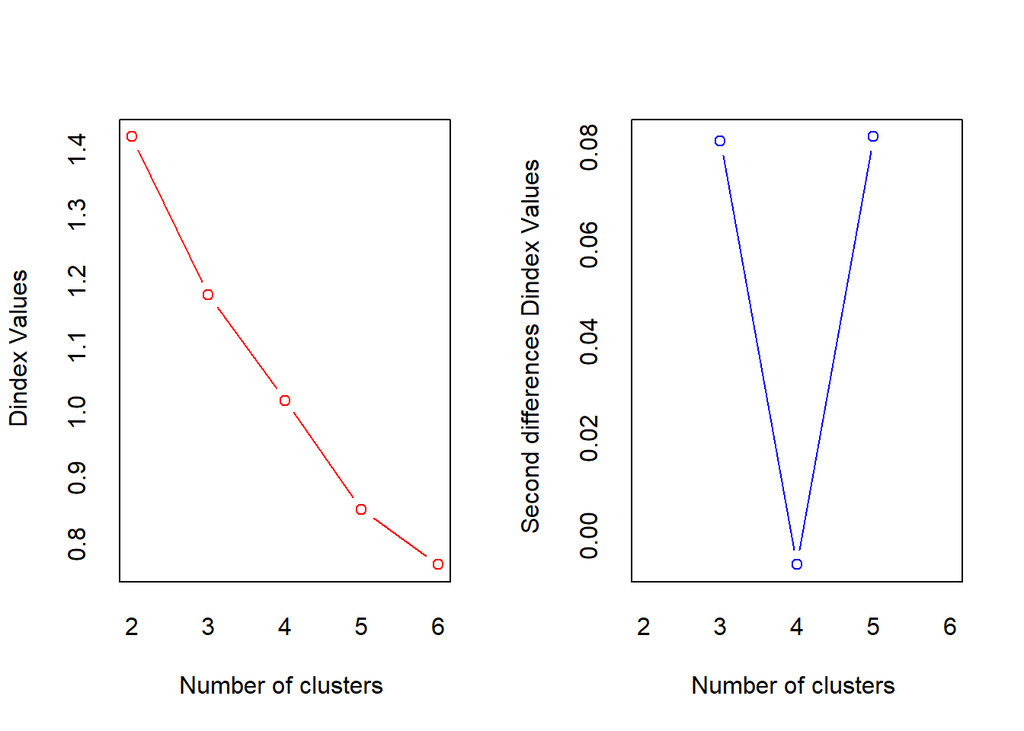

```
*** : The D index is a graphical method of determining the number of clusters.
                In the plot of D index, we seek a significant knee (the significant peak in Dindex
                second differences plot) that corresponds to a significant increase of the value of
                the measure.

* Among all indices:
* 6 proposed 2 as the best number of clusters
* 13 proposed 3 as the best number of clusters
* 2 proposed 4 as the best number of clusters
* 1 proposed 5 as the best number of clusters
* 2 proposed 6 as the best number of clusters

                   ***** Conclusion *****

* According to the majority rule, the best number of clusters is  3
```

```r
#Numero de cluster optimos

clustoptim<-NbClust(base, distance = "euclidea",
                    min.nc = 2, max.nc = 6,
                    method = "ward.D", index = "all")
```

```
Among all indices:
===================
* 2 proposed  0 as the best number of clusters
* 6 proposed  2 as the best number of clusters
* 13 proposed  3 as the best number of clusters
* 2 proposed  4 as the best number of clusters
* 1 proposed  5 as the best number of clusters
* 2 proposed  6 as the best number of clusters

Conclusion
=========================
* According to the majority rule, the best number of clusters is  3 .
```

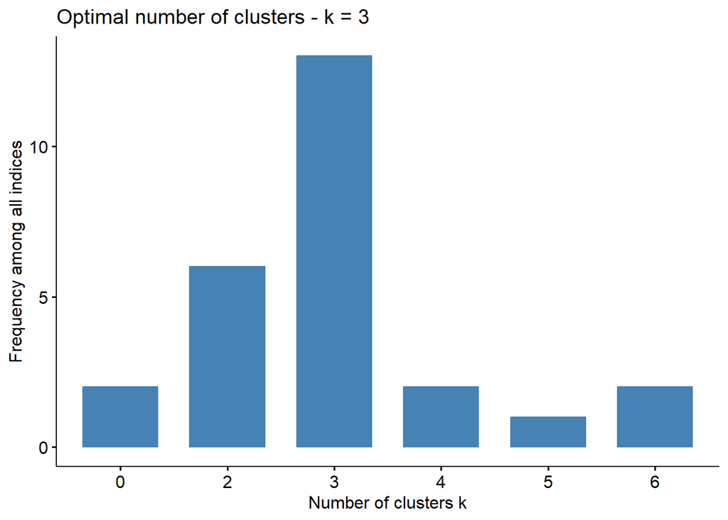

```r
fviz_nbclust(clustoptim)
```

```r
cnj2<-kmeans(base,3)
```

Podemos ver que 13 metodos propusieron que sean 3 cluster, 6 metodos que sean 2 cluster, 2 metodos que 0 y 4 y 6 y solo un metodo que sean 5. Por esta razón vemos que si era optimo los 3 cluster que habiamos impuestos al principio.

### Evaluamos el cluster

```
  cluster size ave.sil.width
1       1   13          0.25
2       2    9          0.04
3       3    1          0.00
```

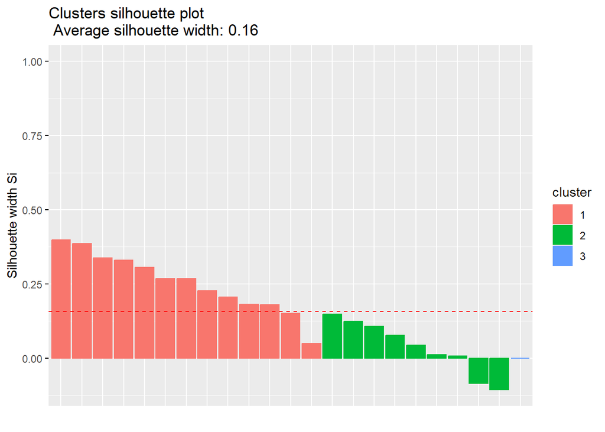

```r
cnj2<-kmeans(base,3)
silueta<- silhouette(cnj2$cluster, dist(base, method = "euclidean"))
fviz_silhouette(silueta)
```

Sin embargo al momento de evaluar al cluster observamos que existen dos observaciones negativas, lo que quiere decir que probablemente no se esten agrupando en el cluster correcto, por lo que debería replantearse el numero de clusters optimos.

```
  cluster size ave.sil.width
1       1    1          0.00
2       2   22          0.68
```

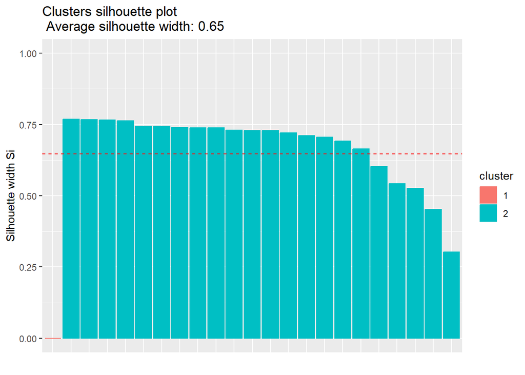

```r
cnj2<-kmeans(base,2)
silueta<- silhouette(cnj2$cluster, dist(base, method = "euclidean"))
fviz_silhouette(silueta)
```